# purrr

# Aula teórica

## Listas

Listas são como vetores, com a diferença de que elas não precisam ser homogêneas (seus elementos podem ter qualquer tipo)

```r
l <- list(
  um_numero = 123,
  um_vetor = c(TRUE, FALSE, TRUE),
  uma_string = "abc",
  uma_lista = list(1, 2, 3)
)

str(l)
```

```
## List of 4
##  $ um_numero : num 123
##  $ um_vetor  : logi [1:3] TRUE FALSE TRUE
##  $ uma_string: chr "abc"
##  $ uma_lista :List of 3
##   ..$ : num 1
##   ..$ : num 2
##   ..$ : num 3
```

Acesse elemento da lista usando `$` ou `[ ]`

```r
l$um_numero; l[2]
```

```
## [1] 123
```

```
## $um_vetor
## [1]  TRUE FALSE  TRUE
```

> **Exercício**: Acesse os outros elementos da lista

Outras formas de criar uma lista

```r
rua <- list(
  casa1 = 'caio',
  casa2 = 'william',
  casa3 = c('julio','athos','fernando','daniel'),
  casa4 = list('bea', casaB = c('barbie','ken'))
)

rua
```

```
## $casa1
## [1] "caio"
##
## $casa2
## [1] "william"
##
## $casa3
## [1] "julio"    "athos"    "fernando" "daniel"
##
## $casa4
## $casa4[[1]]
## [1] "bea"
##
## $casa4$casaB
## [1] "barbie" "ken"
```

Como acessar os elementos das lista? Perceba que usamos `;` para acessar vários ao mesmo tempo.

```r
rua[1]; rua[2]; rua[3]; rua[4]
```

```
## $casa1
## [1] "caio"
```

```
## $casa2
## [1] "william"
```

```
## $casa3
## [1] "julio"    "athos"    "fernando" "daniel"
```

```
## $casa4
## $casa4[[1]]
## [1] "bea"
##
## $casa4$casaB
## [1] "barbie" "ken"
```

Como fazer para acessar o 3 elemento da 3a casa?

```r
rua[[3]][[3]]
```

```
## [1] "fernando"
```

Como acessar o elemento ‘barbie’?

```r
rua[[4]][[2]][[1]]
```

```
## [1] "barbie"
```

Outras soluções:

```r
rua[['casa4']][["casaB"]][[1]]; rua$casa4$casaB[1]
```

```
## [1] "barbie"
```

```
## [1] "barbie"
```

## Pluck()

A função pluck nos ajuda a acessar os dados da lista:

```r
pluck(rua, 'casa4', 'casaB', 1)
```

```
## [1] "barbie"
```

## Iterações

```r
vec <- 1:5

for (i in seq_along(vec)){
  vec[i] <- vec[i] + 10
}

vec
```

```
## [1] 11 12 13 14 15
```

```r
vec2 <- 10:20
seq_along(vec2)
```

```
##  [1]  1  2  3  4  5  6  7  8  9 10 11
```

## Map

O pacote {purrr} nos permite simplificar iterações e integrá-las a pipelines do {tidyverse}: a função map() realiza uma iteração recebendo apenas uma entrada e uma função

```r
vec <- 1:5

soma_dez <- function(x) {
  x + 10
}

l <- map(vec, soma_dez)
l
```

```
## [[1]]
## [1] 11
##
## [[2]]
## [1] 12
##
## [[3]]
## [1] 13
##
## [[4]]
## [1] 14
##
## [[5]]
## [1] 15
```

map() sempre retorna uma lista independente do objeto recebido porque ela não pode assumir nada sobre o resultado, como visto acima.

Se quisermos achatar os resultados só precisamos chamar uma função da família map_***() (onde *** é a abreviação do tipo do objeto que deve ser retornado).

Usando dbl no exemplo acima:

```r
l <- map_dbl(vec, soma_dez)
l
```

```
## [1] 11 12 13 14 15
```

Os tipos possíveis são: dbl (números), chr (strings), dfc (data frame columns), dfr (data frame rows), int (inteiros) e lgl (lógicos).

## Notação lambda

```r
map_dbl(vec, ~3+.x)
```

```
## [1] 4 5 6 7 8
```

O `~` declara a função e `.x` declara o parâmetro da função. Isso permite declarar funções simples de forma direta.

## Duas entradas

A função str_extract recebe duas entradas: o string e o padrão a ser retirada.

```r
strings <- c("oiii", "como vai", "tchau")
padroes <- c("i+",   "(.o){2}",  "[au]+$")
map2_chr(strings, padroes, stringr::str_extract)
```

```
## [1] "iii"  "como" "au"
```

Podemos usar a função lambda aqui também:

```r
map2_chr(strings, padroes, ~stringr::str_c(.y, " | ", .x))
```

```
## [1] "i+ | oiii"          "(.o){2} | como vai" "[au]+$ | tchau"
```

Veja o funcionamento da função str_c para entender o que está sendo feito:

```r
stringr::str_c('a', '|', 'b')
```

```
## [1] "a|b"
```

## List-columns

List-columns são colunas nas quais cada elemento é uma lista (ou até mesmo uma tabela completa)

A função str_split(), por exemplo, retorna uma lista contendo os pedaços da string original quebrada com um regex.

Importando base IMDB diretamente da internet

```r
theURL <- "https://github.com/curso-r/202104-r4ds-2/raw/master/data/imdb.rds"
tmp <- tempfile()
download.file(theURL, tmp)

imdb <- readRDS(tmp)

head(imdb)
```

Salvamos a base no PC e utilizamos daqui:

```r
imdb <- readRDS(file="../data/imdb.RDS")
```

Vamos ver títulos e generos

```r
imdb |>
  select(titulo, generos)
```

```
## # A tibble: 3,713 x 2
##    titulo                                     generos
##    <chr>                                      <chr>
##  1 Avatar                                     Action|Adventure|Fantasy|Sci-Fi
##  2 Pirates of the Caribbean: At World's End   Action|Adventure|Fantasy
##  3 The Dark Knight Rises                      Action|Thriller
##  4 John Carter                                Action|Adventure|Sci-Fi
##  5 Spider-Man 3                               Action|Adventure|Romance
##  6 Tangled                                    Adventure|Animation|Comedy|Family~
##  7 Avengers: Age of Ultron                    Action|Adventure|Sci-Fi
##  8 Batman v Superman: Dawn of Justice         Action|Adventure|Sci-Fi
##  9 Superman Returns                           Action|Adventure|Sci-Fi
## 10 Pirates of the Caribbean: Dead Man's Chest Action|Adventure|Fantasy
## # ... with 3,703 more rows
```

Vamos criar uma nova variável chamada split_generos que divide a variavel por “|”.

```r
imdb |>
  mutate(split_generos = stringr::str_split(generos, "\\|")) |>
  select(titulo, generos, split_generos)
```

```
## # A tibble: 3,713 x 3
##    titulo                                     generos              split_generos
##    <chr>                                      <chr>                <list>
##  1 Avatar                                     Action|Adventure|Fa~ <chr [4]>
##  2 Pirates of the Caribbean: At World's End   Action|Adventure|Fa~ <chr [3]>
##  3 The Dark Knight Rises                      Action|Thriller      <chr [2]>
##  4 John Carter                                Action|Adventure|Sc~ <chr [3]>
##  5 Spider-Man 3                               Action|Adventure|Ro~ <chr [3]>
##  6 Tangled                                    Adventure|Animation~ <chr [7]>
##  7 Avengers: Age of Ultron                    Action|Adventure|Sc~ <chr [3]>
##  8 Batman v Superman: Dawn of Justice         Action|Adventure|Sc~ <chr [3]>
##  9 Superman Returns                           Action|Adventure|Sc~ <chr [3]>
## 10 Pirates of the Caribbean: Dead Man's Chest Action|Adventure|Fa~ <chr [3]>
## # ... with 3,703 more rows
```

Veja como funciona a função split

```r
fruits <- c(
  "apples and oranges and pears and bananas",
  "pineapples and mangos and guavas"
)

stringr::str_split(fruits, " and ")
```

```
## [[1]]
## [1] "apples"  "oranges" "pears"   "bananas"
##
## [[2]]
## [1] "pineapples" "mangos"     "guavas"
```

```r
imdb %>%
  mutate(split_generos = stringr::str_split(generos, "\\|")) %>%
  select(titulo, split_generos) %>%
  tidyr::unnest(split_generos)
```

```
## # A tibble: 10,612 x 2
##    titulo                                   split_generos
##    <chr>                                    <chr>
##  1 Avatar                                   Action
##  2 Avatar                                   Adventure
##  3 Avatar                                   Fantasy
##  4 Avatar                                   Sci-Fi
##  5 Pirates of the Caribbean: At World's End Action
##  6 Pirates of the Caribbean: At World's End Adventure
##  7 Pirates of the Caribbean: At World's End Fantasy
##  8 The Dark Knight Rises                    Action
##  9 The Dark Knight Rises                    Thriller
## 10 John Carter                              Action
## # ... with 10,602 more rows
```

Veja que a tabela foi esticada. Assim posso fazer a contagem, conforme exemplo abaixo:

```r
imdb %>%
  mutate(split_generos = stringr::str_split(generos, "\\|")) %>%
  select(titulo, split_generos) %>%
  tidyr::unnest(split_generos) %>%
  group_by(titulo) %>%
  tidyr::nest(generos = c(split_generos))
```

```
## # A tibble: 3,711 x 2
## # Groups:   titulo [3,711]
##    titulo                                     generos
##    <chr>                                      <list>
##  1 Avatar                                     <tibble [4 x 1]>
##  2 Pirates of the Caribbean: At World's End   <tibble [3 x 1]>
##  3 The Dark Knight Rises                      <tibble [2 x 1]>
##  4 John Carter                                <tibble [3 x 1]>
##  5 Spider-Man 3                               <tibble [3 x 1]>
##  6 Tangled                                    <tibble [7 x 1]>
##  7 Avengers: Age of Ultron                    <tibble [3 x 1]>
##  8 Batman v Superman: Dawn of Justice         <tibble [3 x 1]>
##  9 Superman Returns                           <tibble [3 x 1]>
## 10 Pirates of the Caribbean: Dead Man's Chest <tibble [3 x 1]>
## # ... with 3,701 more rows
```

Finalizando usamos um mutate:

```r
imdb %>%
  mutate(split_generos = stringr::str_split(generos, "\\|")) %>%
  select(titulo, split_generos) %>%
  tidyr::unnest(split_generos) %>%
  group_by(titulo) %>%
  tidyr::nest(generos = c(split_generos)) %>%
  ungroup() %>%
  mutate(n_generos = map_dbl(generos, nrow))
```

```
## # A tibble: 3,711 x 3
##    titulo                                     generos          n_generos
##    <chr>                                      <list>               <dbl>
##  1 Avatar                                     <tibble [4 x 1]>         4
##  2 Pirates of the Caribbean: At World's End   <tibble [3 x 1]>         3
##  3 The Dark Knight Rises                      <tibble [2 x 1]>         2
##  4 John Carter                                <tibble [3 x 1]>         3
##  5 Spider-Man 3                               <tibble [3 x 1]>         3
##  6 Tangled                                    <tibble [7 x 1]>         7
##  7 Avengers: Age of Ultron                    <tibble [3 x 1]>         3
##  8 Batman v Superman: Dawn of Justice         <tibble [3 x 1]>         3
##  9 Superman Returns                           <tibble [3 x 1]>         3
## 10 Pirates of the Caribbean: Dead Man's Chest <tibble [3 x 1]>         3
## # ... with 3,701 more rows
```

# Aula prática

## Lucro médio - naive

Desejamos calcular o lucro médio por gênero.

Poderiamos fazer isso detectando cada gênero, conforme abaixo.

```r
# Calcular o lucro médio por gênero do filme

imdb %>%
  filter(str_detect(generos, "Action")) %>%
  mutate(lucro = receita - orcamento) %>%
  summarise(lucro_medio = mean(lucro, na.rm = TRUE))
```

```
## # A tibble: 1 x 1
##   lucro_medio
##         <dbl>
## 1   15377484.
```

## Lucro médio - esperto

O problema que isso é muito trabalhoso. Teríamos que mapear todos e gêneros e criar um código para cada um deles. Contudo, podemos aproveitar o nest e fazer o seguinte:

```r
imdb %>%
  mutate(generos_separados = str_split(generos, "\\|")) %>%
  unnest(cols = generos_separados) %>%
  group_by(generos_separados) %>%
  summarise(
    lucro_medio = mean(receita - orcamento, na.rm = TRUE)
  )
```

```
## # A tibble: 26 x 2
##    generos_separados lucro_medio
##    <chr>                   <dbl>
##  1 Action              15377484.
##  2 Adventure           26686222.
##  3 Animation           35239151.
##  4 Biography           16953735.
##  5 Comedy              19481075.
##  6 Crime               10997025.
##  7 Documentary         10662126.
##  8 Drama               12875036.
##  9 Family              29444559.
## 10 Fantasy             24466387.
## # ... with 16 more rows
```

## Cuidado com separate()

Cuidado com a função separate que é diferente:

```r
# é diferente de usar o tidyr::separate
imdb |>
  # remove FALSE faz com que genero continue na base
  separate(generos, c("g1", "g2", "g3"), "\\|", remove = FALSE) |>
  select(titulo, generos, g1, g2, g3)
```

```
## # A tibble: 3,713 x 5
##    titulo                                     generos         g1     g2    g3
##    <chr>                                      <chr>           <chr>  <chr> <chr>
##  1 Avatar                                     Action|Adventu~ Action Adve~ Fant~
##  2 Pirates of the Caribbean: At World's End   Action|Adventu~ Action Adve~ Fant~
##  3 The Dark Knight Rises                      Action|Thriller Action Thri~ <NA>
##  4 John Carter                                Action|Adventu~ Action Adve~ Sci-~
##  5 Spider-Man 3                               Action|Adventu~ Action Adve~ Roma~
##  6 Tangled                                    Adventure|Anim~ Adven~ Anim~ Come~
##  7 Avengers: Age of Ultron                    Action|Adventu~ Action Adve~ Sci-~
##  8 Batman v Superman: Dawn of Justice         Action|Adventu~ Action Adve~ Sci-~
##  9 Superman Returns                           Action|Adventu~ Action Adve~ Sci-~
## 10 Pirates of the Caribbean: Dead Man's Chest Action|Adventu~ Action Adve~ Fant~
## # ... with 3,703 more rows
```

## Gráfico como tibble

```r
# Gráfico nota_imdb vs orçamento por ano a partir de 1970

fazer_grafico <- function(tab) {
  tab %>%
    ggplot(aes(x = orcamento, y = nota_imdb)) +
    geom_point()
}

tab_graficos <- imdb %>%
  filter(ano >= 1970) %>%
  group_by(ano) %>%
  nest() %>%
  mutate(
    grafico = map(data, fazer_grafico)
  )

tab_graficos
```

```
## # A tibble: 47 x 3
## # Groups:   ano [47]
##      ano data                grafico
##    <int> <list>              <list>
##  1  2009 <tibble [178 x 14]> <gg>
##  2  2007 <tibble [146 x 14]> <gg>
##  3  2012 <tibble [168 x 14]> <gg>
##  4  2010 <tibble [162 x 14]> <gg>
##  5  2015 <tibble [158 x 14]> <gg>
##  6  2016 <tibble [74 x 14]>  <gg>
##  7  2006 <tibble [164 x 14]> <gg>
##  8  2013 <tibble [167 x 14]> <gg>
##  9  2008 <tibble [161 x 14]> <gg>
## 10  2011 <tibble [164 x 14]> <gg>
## # ... with 37 more rows
```

Cada linha dessa tabela possuí um gráfico. Para acessar o gráfico fazemos:

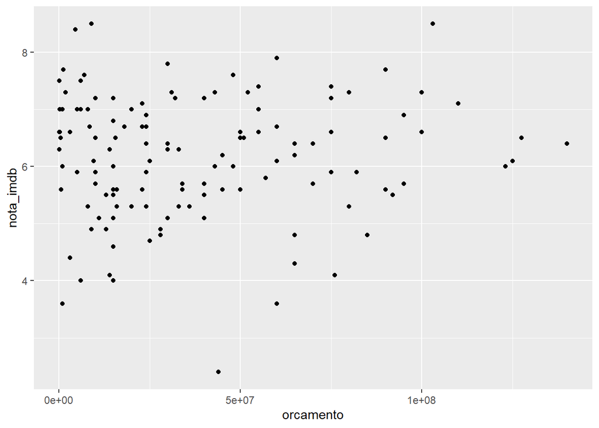

```r
tab_graficos %>%
  filter(ano == 2000) %>%
  pluck("grafico", 1)
```

## Importar várias bases

### Dividir as bases

Primeiro vamos fazer um exercício de dividir a base imdb por ano em vários arquivos. Veja [aqui](https://community.rstudio.com/t/map-write-csv/33292/2) um post sobre isso.

```r
imdb |>
  filter(ano>=1970) |>
  group_by(ano) |>
  nest() |>
  pwalk(~saveRDS(object = .y,
                 file = paste0("../data/teste/imbd",.x, ".rds")))

imdb |>
  filter(ano>=1970) |> nrow()
```

[output not shown]

Observe que há 3527 linhas.

### Juntar as bases

Agora vamos fazer o contrário e importar todas essas bases:

```r
# Usando o purrr para ler (e empilhar) várias bases de dados

arquivos <- list.files("../data/teste/", pattern = "imbd", full.names = TRUE)

ler_arquivo <- function(caminho) {
  # extraí o ano do caminho
  ano_ <- str_extract(caminho, "[0-9]{4}")

  #leiturado dos arquivo a partir do caminho e inclusão de coluna com ano
  readr::read_rds(caminho) %>%
    mutate(
      ano_extraido_do_arq = as.integer(ano_)
    )
}

arquivos
```

```
##  [1] "../data/teste/imbd1970.rds" "../data/teste/imbd1971.rds"
##  [3] "../data/teste/imbd1972.rds" "../data/teste/imbd1973.rds"
##  [5] "../data/teste/imbd1974.rds" "../data/teste/imbd1975.rds"
##  [7] "../data/teste/imbd1976.rds" "../data/teste/imbd1977.rds"
##  [9] "../data/teste/imbd1978.rds" "../data/teste/imbd1979.rds"
## [11] "../data/teste/imbd1980.rds" "../data/teste/imbd1981.rds"
## [13] "../data/teste/imbd1982.rds" "../data/teste/imbd1983.rds"
## [15] "../data/teste/imbd1984.rds" "../data/teste/imbd1985.rds"
## [17] "../data/teste/imbd1986.rds" "../data/teste/imbd1987.rds"
## [19] "../data/teste/imbd1988.rds" "../data/teste/imbd1989.rds"
## [21] "../data/teste/imbd1990.rds" "../data/teste/imbd1991.rds"
## [23] "../data/teste/imbd1992.rds" "../data/teste/imbd1993.rds"
## [25] "../data/teste/imbd1994.rds" "../data/teste/imbd1995.rds"
## [27] "../data/teste/imbd1996.rds" "../data/teste/imbd1997.rds"
## [29] "../data/teste/imbd1998.rds" "../data/teste/imbd1999.rds"
## [31] "../data/teste/imbd2000.rds" "../data/teste/imbd2001.rds"
## [33] "../data/teste/imbd2002.rds" "../data/teste/imbd2003.rds"
## [35] "../data/teste/imbd2004.rds" "../data/teste/imbd2005.rds"
## [37] "../data/teste/imbd2006.rds" "../data/teste/imbd2007.rds"
## [39] "../data/teste/imbd2008.rds" "../data/teste/imbd2009.rds"
## [41] "../data/teste/imbd2010.rds" "../data/teste/imbd2011.rds"
## [43] "../data/teste/imbd2012.rds" "../data/teste/imbd2013.rds"
## [45] "../data/teste/imbd2014.rds" "../data/teste/imbd2015.rds"
## [47] "../data/teste/imbd2016.rds"
```

```r
# O map gera uma lista com as bases
purrr::map(
  arquivos,
  ler_arquivo
) %>%
  # o bind_rows junta as listas empilhando
  bind_rows()
```

```
## # A tibble: 3,527 x 15
##    titulo   diretor duracao cor   generos  pais  classificacao orcamento receita
##    <chr>    <chr>     <int> <chr> <chr>    <chr> <chr>             <int>   <int>
##  1 Darling~ Blake ~     143 Color Comedy|~ USA   Outros         25000000  5   e6
##  2 Catch-22 Mike N~     122 Color Comedy|~ USA   A partir de ~  18000000 NA
##  3 Patton   Frankl~     172 Color Biograp~ USA   Outros         12000000 NA
##  4 The Mol~ Martin~     124 Color Drama|H~ USA   Livre          11000000 NA
##  5 The Bal~ Sam Pe~     121 Color Comedy|~ USA   A partir de ~   3716946 NA
##  6 Beneath~ Ted Po~      95 Color Action|~ USA   Outros          3000000 NA
##  7 Cotton ~ Ossie ~      97 Color Action|~ USA   A partir de ~   1200000 NA
##  8 Beyond ~ Russ M~     109 Color Comedy|~ USA   Outros           900000  9   e6
##  9 Woodsto~ Michae~     215 Color Documen~ USA   A partir de ~    600000  1.33e7
## 10 The Fre~ Willia~     104 Color Action|~ USA   A partir de ~   1800000 NA
## # ... with 3,517 more rows, and 6 more variables: nota_imdb <dbl>,
## #   likes_facebook <int>, ator_1 <chr>, ator_2 <chr>, ator_3 <chr>,
## #   ano_extraido_do_arq <int>
```

Podemos fazer diretamente pelo map_dfr

```r
map_dfr(
  arquivos,
  readr::read_rds
)
```

```
## # A tibble: 3,527 x 14
##    titulo   diretor duracao cor   generos  pais  classificacao orcamento receita
##    <chr>    <chr>     <int> <chr> <chr>    <chr> <chr>             <int>   <int>
##  1 Darling~ Blake ~     143 Color Comedy|~ USA   Outros         25000000  5   e6
##  2 Catch-22 Mike N~     122 Color Comedy|~ USA   A partir de ~  18000000 NA
##  3 Patton   Frankl~     172 Color Biograp~ USA   Outros         12000000 NA
##  4 The Mol~ Martin~     124 Color Drama|H~ USA   Livre          11000000 NA
##  5 The Bal~ Sam Pe~     121 Color Comedy|~ USA   A partir de ~   3716946 NA
##  6 Beneath~ Ted Po~      95 Color Action|~ USA   Outros          3000000 NA
##  7 Cotton ~ Ossie ~      97 Color Action|~ USA   A partir de ~   1200000 NA
##  8 Beyond ~ Russ M~     109 Color Comedy|~ USA   Outros           900000  9   e6
##  9 Woodsto~ Michae~     215 Color Documen~ USA   A partir de ~    600000  1.33e7
## 10 The Fre~ Willia~     104 Color Action|~ USA   A partir de ~   1800000 NA
## # ... with 3,517 more rows, and 5 more variables: nota_imdb <dbl>,
## #   likes_facebook <int>, ator_1 <chr>, ator_2 <chr>, ator_3 <chr>
```

Ou ainda:

```r
purrr::map_dfr(
  arquivos,
  ler_arquivo
)
```

```
## # A tibble: 3,527 x 15
##    titulo   diretor duracao cor   generos  pais  classificacao orcamento receita
##    <chr>    <chr>     <int> <chr> <chr>    <chr> <chr>             <int>   <int>
##  1 Darling~ Blake ~     143 Color Comedy|~ USA   Outros         25000000  5   e6
##  2 Catch-22 Mike N~     122 Color Comedy|~ USA   A partir de ~  18000000 NA
##  3 Patton   Frankl~     172 Color Biograp~ USA   Outros         12000000 NA
##  4 The Mol~ Martin~     124 Color Drama|H~ USA   Livre          11000000 NA
##  5 The Bal~ Sam Pe~     121 Color Comedy|~ USA   A partir de ~   3716946 NA
##  6 Beneath~ Ted Po~      95 Color Action|~ USA   Outros          3000000 NA
##  7 Cotton ~ Ossie ~      97 Color Action|~ USA   A partir de ~   1200000 NA
##  8 Beyond ~ Russ M~     109 Color Comedy|~ USA   Outros           900000  9   e6
##  9 Woodsto~ Michae~     215 Color Documen~ USA   A partir de ~    600000  1.33e7
## 10 The Fre~ Willia~     104 Color Action|~ USA   A partir de ~   1800000 NA
## # ... with 3,517 more rows, and 6 more variables: nota_imdb <dbl>,
## #   likes_facebook <int>, ator_1 <chr>, ator_2 <chr>, ator_3 <chr>,
## #   ano_extraido_do_arq <int>
```

Perceba que o valor de linhas continua igual ao inicial.

# Referências

- [Webinar de purrr avançado](https://www.youtube.com/watch?v=vb1lD9_AFcU)
- [A Magia de purrr](https://lente.dev/posts/magica-purrr/)
- [Exercícios de iteração R4DS](https://r4ds.had.co.nz/iteration.html)
- [Tutorial de purrr](https://jennybc.github.io/purrr-tutorial/)
- [Exemplos de purrr](https://lente.dev/advanced-purrr.pdf)